# Выявление определяющих успешность компьютерной игры закономерностей

## Описание проекта

Мы работаем в интернет-магазине «Стримчик», который продаёт по всему миру компьютерные игры. Из открытых источников доступны исторические данные о продажах игр, оценки пользователей и экспертов, жанры и платформы (например, Xbox или PlayStation). Вам нужно выявить определяющие успешность игры закономерности. Это позволит сделать ставку на потенциально популярный продукт и спланировать рекламные кампании.

## Содержание

1. Изучение общей информации
2. Предобработка данных
   1. Переведем название колонок в нижний регистр
   2. Обработаем пропуски и дубликаты в данных
3. Исследовательский анализ данных
   1. Количество выпуска игр в разные годы
   2. Изменение продаж по платформам
   3. Вывод актуального периода для работы
   4. Построим ящики с усами в разбивке каждой платформы
   5. Влияние отзывов пользователей и критиков на продажи внутри одной популярной платформы
   6. Общее распредление игр по жанрам
4. Составление портрета пользователя каждого региона
   1. Определение топ - 5 самых популярных платформ для каждого региона
   2. Опредение топ-5 популярных жанров игр в каждом регионе
   3. Влияет ли рейтинг ESRB на продажи в отдельном регионе?
5. Проверка гипотез
   1. Гипотеза 1
   2. Гипотеза 2
6. Общий вывод
7. Рекомендации

## Шаг 0. Импорт всех необходимых библиотек

```python
import pandas as pd
import numpy as np
import matplotlib.pyplot as plt
from scipy import stats as st
```

## Шаг 1. Изучение общей информации о данных

```python
game_data = pd.read_csv('datasets/games.csv')
game_data.info()
game_data.head()
```

#### Вывод

Всего в датасете у нас 16715 строк,большое количество пропусков в колонках `Critic_Score`, `User_Score`, `Rating`. Небходимо привести некоторе столбцы к необходимым типам данных. Приступим к предобработке.

## Шаг 2. Предобработка данных

#### Переведем название колонок в нижний регистр

```python
game_data.columns = game_data.columns.str.lower()
game_data.columns
```

#### Обработаем пропуски в данных

```python
# год выпуска зависит от платформы на которой запускалась игра
#построим сводную таблицу по платформе и заполним пропуски средним годом в зависимости от платформы
platform_grouped = game_data.pivot_table(index='platform',values='year_of_release',aggfunc='mean').round().astype('int')
platform_grouped.head()
```

```python
# заполним пропуски
def setting_year_of_release(row):
    platform = row['platform']
    year_of_release = row['year_of_release']

    if pd.isna(year_of_release):
        row['year_of_release'] = int(platform_grouped[platform_grouped.index == platform]['year_of_release'][0])
    else:
        row['year_of_release'] = int(row['year_of_release'])

    return row

game_data = game_data.apply(setting_year_of_release,axis=1)
game_data.head()
```

```python
# оценках критиков зависит от жанра игры

# TBD - аббревиатура от английского To Be Determined (будет определено) или To Be Decided (будет решено)
# для начала заполним эту аббревиатуру нулем
game_data['critic_score'] = game_data['critic_score'].apply(lambda x: 0 if x == 'tbd' else x)

# приведем все к типу float
game_data['critic_score'] = game_data['critic_score'].astype('float')

#построим сводную таблицу оценок критиков по жанру
genre_grouped = game_data.pivot_table(index='genre',values='critic_score',aggfunc='mean').round(1)
genre_grouped.head()
```

```python
# заполним пропуски
def setting_critic_score(row):
    genre = row['genre']
    critic_score = row['critic_score']

    if pd.isna(critic_score):
        try:
            row['critic_score'] = genre_grouped[genre_grouped.index == genre]['critic_score'][0]
        except:
            pass

    return row

game_data = game_data.apply(setting_critic_score,axis=1)
game_data.head()
```

```python
# оценках пользователей зависит от жанра игры

# TBD - аббревиатура от английского To Be Determined (будет определено) или To Be Decided (будет решено)
# для начала заполним эту аббревиатуру нулем
game_data['user_score'] = game_data['user_score'].apply(lambda x: 0 if x == 'tbd' else x)

# приведем все к типу float
game_data['user_score'] = game_data['user_score'].astype('float')

#построим сводную таблицу оценок пользователей по жанру
genre_grouped_for_users = game_data.pivot_table(index='genre',values='user_score',aggfunc='mean').round(1)
genre_grouped_for_users.head()
```

```python
# заполним пропуски
def setting_user_score(row):
    genre = row['genre']
    user_score = row['user_score']

    if pd.isna(user_score):
        try:
            row['user_score'] = genre_grouped_for_users[genre_grouped_for_users.index == genre]['user_score'][0]
        except:
            pass

    return row

game_data = game_data.apply(setting_user_score,axis=1)
game_data.head()
```

```python
# чтобы оценка критиков тоже лежала в промежутке от 0 до 10
game_data['critic_score'] = (game_data['critic_score'] / 10).round(1)
game_data.head()
```

```python
# все продажи заменим типом данных int, так как количество - целое число
game_data[['na_sales', 'eu_sales','jp_sales', 'other_sales']] = game_data[['na_sales', 'eu_sales','jp_sales', 'other_sales']].astype('int')
```

```python
# заполнять пропуски в значениях рейтинга не будем,будем считать,что значение рейтинга еще не вынесли
game_data['rating'].unique()
```

```python
#удалим те строки в которых не указано имя игры
game_data = game_data[pd.isna(game_data['name']) == False]
game_data.info()
```

```python
# дубликатов нет
game_data.duplicated().sum()
```

```python
# добавим общее количество продаж для каждой игры
game_data['total_sales'] = game_data['na_sales'] + game_data['eu_sales'] + game_data['jp_sales'] + game_data['other_sales']
game_data.head()
```

#### Вывод

Были заменены типы данных с float на int,где это было необходимо.

Дубликатов обнаружено не было😳

## Шаг 3. Исследовательский анализ данных

#### Количество выпуска игр в разные годы

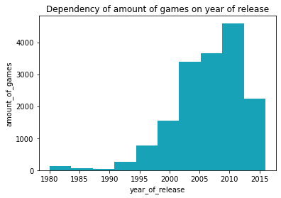

```python
# построим гистограмму распределения
plt.hist(data=game_data,x='year_of_release',color='#17a2b8',histtype='bar')
plt.title('Dependency of amount of games on year of release')
plt.xlabel('year_of_release')
plt.ylabel('amount_of_games');
```

#### Вывод

По графику мы наблюдаем то,что больше всего игр было выпущено в период с 2010 по 2013 годы. Что касается важности данных,мы видим,что в период с 1980 по 1990 игр практически не выпускалось и если мы обрежем эту часть из данных - результаты не сильно изменятся,зато распределение станет более близким к нормальному.

#### Изменение продаж по платформам

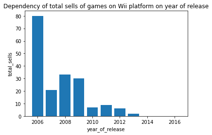

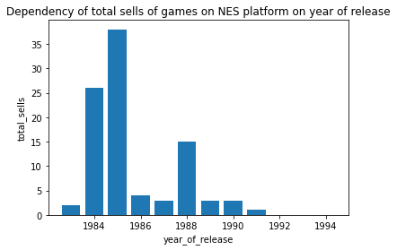

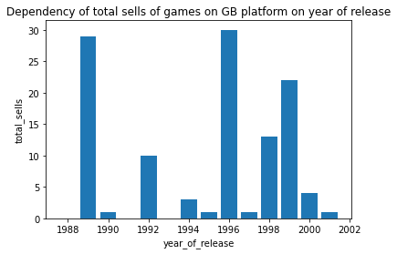

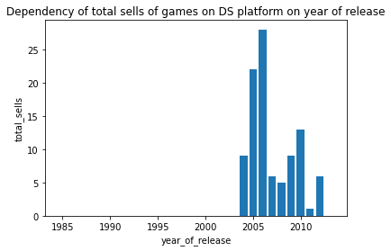

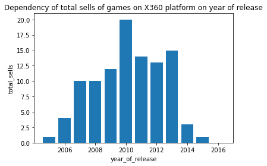

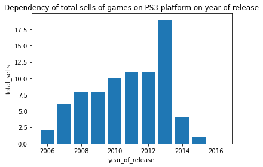

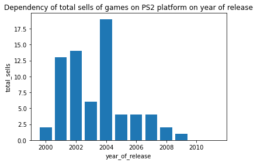

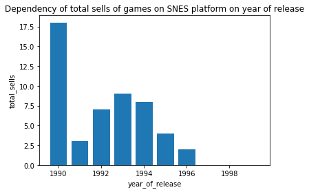

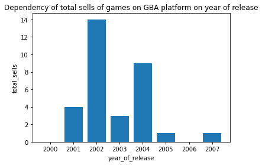

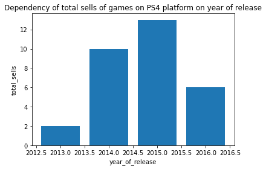

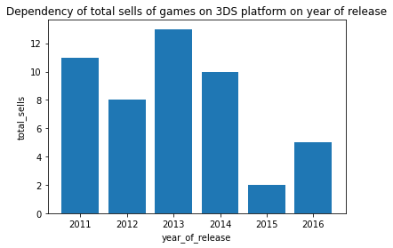

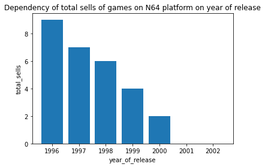

[19 more figures not shown]

```python
# построим график продаж для каждой из платформ
for platform in game_data['platform'].unique():
    necess_games = game_data[game_data['platform'] == platform].sort_values(by='year_of_release',ascending=True)
    plt.bar(necess_games['year_of_release'],necess_games['total_sales'])
    plt.xlabel('year_of_release')
    plt.ylabel('total_sells')
    plt.title(f'Dependency of total sells of games on {platform} platform on year of release')
    plt.show()
```

#### Вывод

В среднем мы наблюдаем,что игры на платформу продаются в течение 10-12 лет,но взглянув а графики,мы видим,что существуют и такие платформы,на которые вообще игр не продавалось.Тут два варианта - либо ошибка выгрузки данных,либо правда так оно и произошло.Сейчас будем удалять ненужные платформы.

```python
game_data = game_data.query('platform != "PCFX" and platform != "GG" and platform != "3DO" and platform != "TG16" and platform != "NG" and platform != "WS" and platform != "PSV"')
game_data['platform'].unique()
```

#### Выделим актуальный период и будем работать с ним

Логичнее всего взять период с 2014 года (включая его),так как это довольно таки стабильный период и именно этот период как раз более подходящий,потому что не так много платформ устареют,а может быть и все будут еще актуальны.

```python
actual_data = game_data.query(' year_of_release >= 2014 ').reset_index(drop=True)
actual_data.info()
actual_data.head()
```

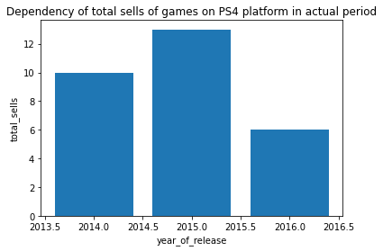

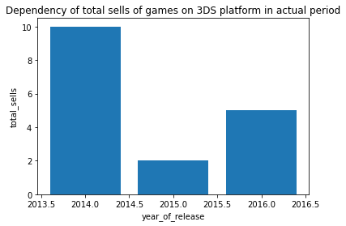

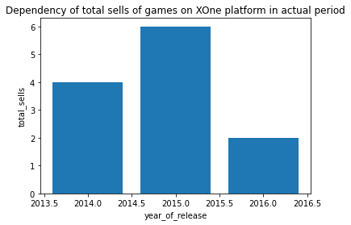

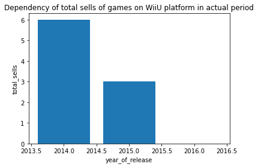

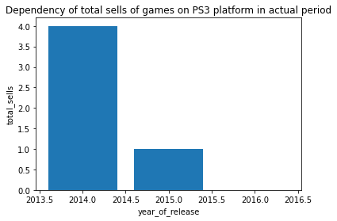

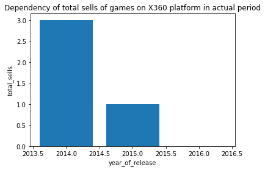

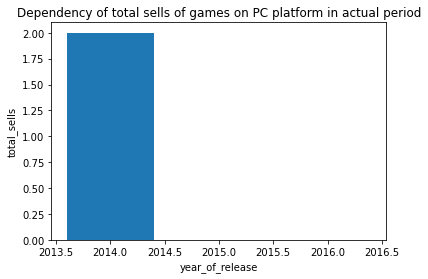

[figure not shown]

[figure not shown]

[figure not shown]

```python
# построим график продаж для каждой из платформ
for platform in actual_data['platform'].unique():
    necess_games = actual_data[actual_data['platform'] == platform].sort_values(by='year_of_release',ascending=True)
    plt.bar(necess_games['year_of_release'],necess_games['total_sales'])
    plt.xlabel('year_of_release')
    plt.ylabel('total_sells')
    plt.title(f'Dependency of total sells of games on {platform} platform in actual period')
    plt.show()
```